# Simulation and analysis of random fields

Abstract

“Simulation and analysis of random fields” published in R News.

Random fields are the $d$-dimensional analogues of the one-dimensional stochastic processes; they are used to model spatial data as observed in environmental, atmospheric, and geological sciences. They are traditionally needed in mining and exploration to model ore deposits, oil reservoirs, and related structures.

The contributed package **RandomFields** allows for the simulation of Gaussian random fields defined on Euclidean spaces up to dimension 3. It includes some geostatistical tools and algorithms for the simulation of extreme-value random fields.

In the following two sections we give an example of an application, and a summary of the features of **RandomFields**.

## A brief geostatistical analysis

To demonstrate key features we consider soil moisture data collected by the Soil Physics Group at the University of Bayreuth (see Figure 1), and perform a simple geostatistical analysis.

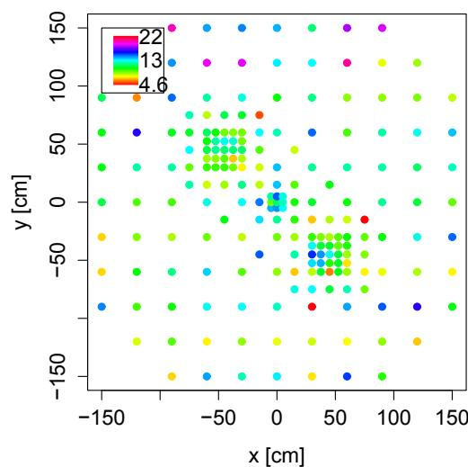

Figure 1: Measured soil moisture content (%)

The coordinates of the sample locations are assumed to be stored in `pts` and the moisture measurements in `d`. (See the example to the data set `soil` for the complete code.)

In geostatistics the variogram $\gamma$ is frequently used to describe the spatial correlation structure. It can be expressed in terms of the (auto-)covariance function $C$ if the random field is stationary: $\gamma(h) = C(0) - C(h)$ for $h \in \mathbb{R}^d$. We assume isotropy, i.e. $\gamma$ depends only on the distance $|h|$. Then, we can find variogram values by and select an appropriate model by see Figure 4 where `x` and `y` equal `seq(-150, 150, l=121)`. The parameters of the variogram model (here the Whittle-Matérn model) might be fitted by eye, but we prefer maximum likelihood,

```
ev <- EmpiricalVariogram(pts, data=d,
                           grid=FALSE,
                           bin=c(-1, seq(0, 175, l=20)))
```

```
ShowModels(0:175, x=x, y=y, emp=ev)
```

```
p <- mleRF(pts, d, "whittle", param=rep(NA,5),
            lower.k=0.01, upper.k=30).
```

Now, yields the expected moisture content on the grid given by `x` and `y` (Figure 2).

```
Kriging("0", x=x, y=y, grid=TRUE,
        model="whittle", par=p, given=pts,
        data=d)
```

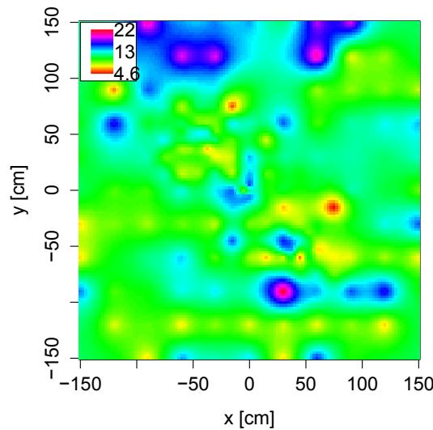

Figure 2: Kriged field

Conditional simulation, see Figure 3, allows for further inference.

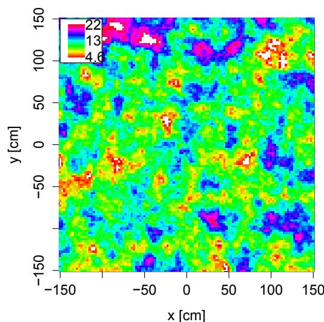

Figure 3: Conditional simulation

For instance, we may ask for the conditional probability, given the data at the respective locations, that the maximal moisture content is not greater than 24%. To this end, a random sample, here of size 100, is drawn from the conditional distribution which yields an estimate of 40%.

```
CondSimu("0", x=x, y=y, grid=TRUE, n=100,
          model="whittle", param=p, given=pts,
          data=d),
```

## Package features

The currently implemented methods for the simulation of stationary and isotropic random fields include circulant embedding, turning bands, and methods based on matrix decomposition or Poisson point processes. Important features of the package are

- User friendly interface: depending on his/her preferences, the user can either specify the desired simulation method, or the package will automatically pick an appropriate technique, according to the variogram model, the dimension of the space, and the spatial configuration of the simulation domain (1).
- Increased speed if multiple simulations with identical specifications are performed. To this end, a specification is first compared to that of the preceding simulation. In case the parameters match, the stored results of the deterministic part of the algorithm are used instead of being recalculated.
- The function `ShowModels` is an instructive tool for teaching, which allows for the interactive choice of variogram models and parameters. For each specification the graph of the variogram model and one- or two-dimensional simulations are provided. `ShowModels` can also be used to fit an empirical variogram by eye.

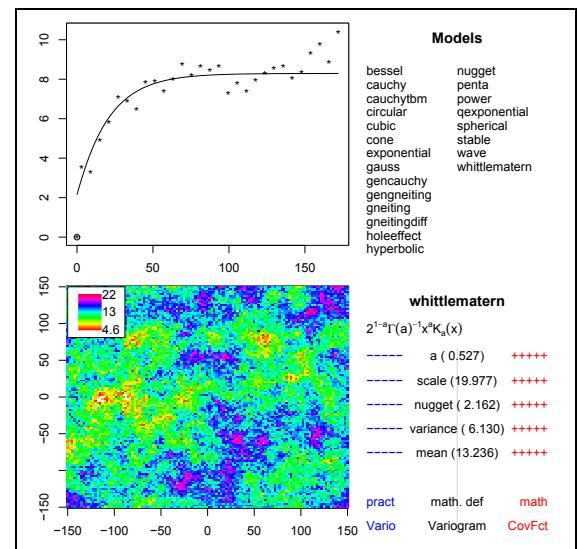

Figure 4: Snapshot of the interactive plot ShowModels

Further functionalities include:

- variogram analysis: calculation of the empirical variogram and MLE parameter estimation
- conditional simulation based on simple or ordinary kriging
- checks whether the parameter specifications are compatible with the variogram model
- simulation of max-stable random fields

Future extensions may provide further simulation algorithms for Gaussian and non-Gaussian random fields, and a basic toolbox for the analysis of geostatistical and spatial extreme value data.

Use `help(RandomFields)` to obtain the main man page. To start with, the examples in `help(GaussRF)` are recommended.

**Acknowledgement.** The work has been supported by the EU TMR network ERB-FMRX-CT96-0095 on “Computational and statistical methods for the analysis of spatial data” and the German Federal Ministry of Research and Technology (BMFT) grant PT BEO 51-0339476C. The author is thankful to Tilmann

Gneiting, Martin Mächler, and Paulo Ribeiro for hints and discussions.

## References

- $$1$$
  M. Schlather. An introduction to positive definite functions and to unconditional simulation of random fields. Technical Report ST-99-10, Lancaster University, 1999.